# HousingPricePrediction

Hyun Ko

2022-08-21

```r
#install.packages("sf")
#install.packages("mapview")

library(sf)
library(mapview)
house <- read.csv('kc_house_data.csv')
head(house)
```

```
##           id            date   price bedrooms bathrooms sqft_living sqft_lot
## 1 7129300520 20141013T000000  221900        3      1.00        1180     5650
## 2 6414100192 20141209T000000  538000        3      2.25        2570     7242
## 3 5631500400 20150225T000000  180000        2      1.00         770    10000
## 4 2487200875 20141209T000000  604000        4      3.00        1960     5000
## 5 1954400510 20150218T000000  510000        3      2.00        1680     8080
## 6 7237550310 20140512T000000 1225000        4      4.50        5420   101930
##   floors waterfront view condition grade sqft_above sqft_basement yr_built
## 1      1          0    0         3     7       1180             0     1955
## 2      2          0    0         3     7       2170           400     1951
## 3      1          0    0         3     6        770             0     1933
## 4      1          0    0         5     7       1050           910     1965
## 5      1          0    0         3     8       1680             0     1987
## 6      1          0    0         3    11       3890          1530     2001
##   yr_renovated zipcode     lat     long sqft_living15 sqft_lot15
## 1            0   98178 47.5112 -122.257          1340       5650
## 2         1991   98125 47.7210 -122.319          1690       7639
## 3            0   98028 47.7379 -122.233          2720       8062
## 4            0   98136 47.5208 -122.393          1360       5000
## 5            0   98074 47.6168 -122.045          1800       7503
## 6            0   98053 47.6561 -122.005          4760     101930
```

## 1. Exploratory Data Analysis

## EDA

- id: Unique ID for each home sold
- date: Date of the home sale
- price: Price of each home sold
- bedrooms: Number of bedroom bathrooms: Number of bathrooms, where .5 accounts for a room with a toilet but no shower
- sqft_living: Square footage of the apartments interior living space
- sqft_lot: Square footage of the land space
- floors: Number of floors
- waterfront: A dummy variable for whether the apartment was overlooking the waterfront or not
- view: An index from 0 to 4 of how good the view of the property was
- condition: An index from 1 to 5 on the condition of the apartment,
- grade: An index from 1 to 13, where 1-3 falls short of building construction and design, 7 has an average level of  
  construction and design, and 11-13 have a high quality level of construction and design.
- sqft_above: The square footage of the interior housing space that is above ground level
- sqft_basement: The square footage of the interior housing space that is below ground level
- yr_built: The year the house was initially built
- yr_renovated: The year of the house’s last renovation
- zipcode: What zipcode area the house is in
- lat: Lattitude
- long: Longitude
- sqft_living15: The square footage of interior housing living space for the nearest 15 neighbors
- sqft_lot15: The square footage of the land lots of the nearest 15 neighbors

```r
library(ggmap)
register_google(key = "AIzaSyCtxAzTR-ZGYP0mZ0S2o3Ri9FzBkp_tK44")
p1 <- get_googlemap("king county") %>% ggmap
```

[figure not shown]

```r
p1 + geom_point(data = house, aes(x = long, y = lat), alpha = 0.03, colour = "red")
```

```r
zipcode <- unique(house$zipcode)
zipcode
```

```
##  [1] 98178 98125 98028 98136 98074 98053 98003 98198 98146 98038 98007 98115
## [13] 98107 98126 98019 98103 98002 98133 98040 98092 98030 98119 98112 98052
## [25] 98027 98117 98058 98001 98056 98166 98023 98070 98148 98105 98042 98008
## [37] 98059 98122 98144 98004 98005 98034 98075 98116 98010 98118 98199 98032
## [49] 98045 98102 98077 98108 98168 98177 98065 98029 98006 98109 98022 98033
## [61] 98155 98024 98011 98031 98106 98072 98188 98014 98055 98039
```

```r
# https://www.niche.com/places-to-live/search/best-zip-codes-to-live/c/king-county-wa/
# Overall Grade > A-
good_zip <- c(98004, 98005, 98052, 98121, 98007, 98109, 98033, 98122, 98029, 98006, 98103, 98102, 98074, 98101, 98040, 98115, 98112, 98107, 98119, 98105, 98075, 98008, 98116, 98053, 98034, 98039, 98144, 98199, 98117, 98104, 98028, 98027, 98011, 98177, 98125, 98065, 98072, 98077, 98126, 98155, 98136, 98059, 98133, 98188, 98106)
# , 98024, 98019, 98038, 98055, 98010, 98108, 98056, 98045, 98058, 98092, 98057, 98031, 98178, 98166, 98003, 98146, 98032, 98042, 98002, 98188, 98001
```

```r
house2 <- house

house2$good_neigh = ifelse(house2$zipcode %in% good_zip, 1, 0)

head(house2)
```

```
##           id            date   price bedrooms bathrooms sqft_living sqft_lot
## 1 7129300520 20141013T000000  221900        3      1.00        1180     5650
## 2 6414100192 20141209T000000  538000        3      2.25        2570     7242
## 3 5631500400 20150225T000000  180000        2      1.00         770    10000
## 4 2487200875 20141209T000000  604000        4      3.00        1960     5000
## 5 1954400510 20150218T000000  510000        3      2.00        1680     8080
## 6 7237550310 20140512T000000 1225000        4      4.50        5420   101930
##   floors waterfront view condition grade sqft_above sqft_basement yr_built
## 1      1          0    0         3     7       1180             0     1955
## 2      2          0    0         3     7       2170           400     1951
## 3      1          0    0         3     6        770             0     1933
## 4      1          0    0         5     7       1050           910     1965
## 5      1          0    0         3     8       1680             0     1987
## 6      1          0    0         3    11       3890          1530     2001
##   yr_renovated zipcode     lat     long sqft_living15 sqft_lot15 good_neigh
## 1            0   98178 47.5112 -122.257          1340       5650          0
## 2         1991   98125 47.7210 -122.319          1690       7639          1
## 3            0   98028 47.7379 -122.233          2720       8062          1
## 4            0   98136 47.5208 -122.393          1360       5000          1
## 5            0   98074 47.6168 -122.045          1800       7503          1
## 6            0   98053 47.6561 -122.005          4760     101930          1
```

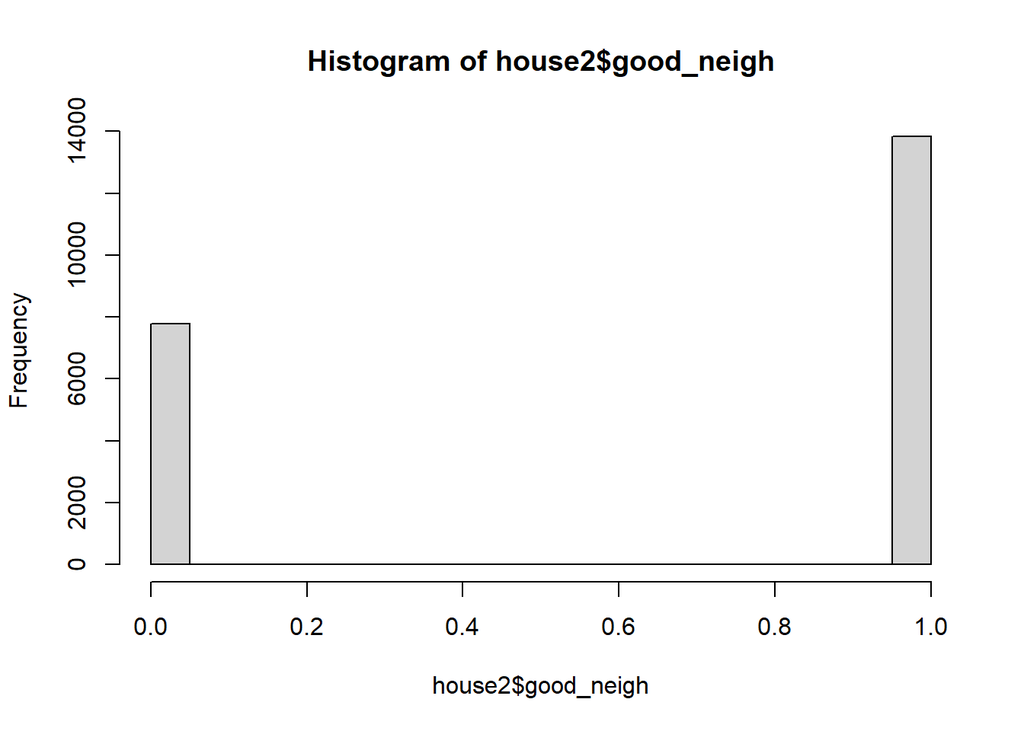

```r
hist(house2$good_neigh)
```

```r
house <- house %>% dplyr::select(-id, -date, -lat, -long, -zipcode)
head(house)
```

```
##     price bedrooms bathrooms sqft_living sqft_lot floors waterfront view
## 1  221900        3      1.00        1180     5650      1          0    0
## 2  538000        3      2.25        2570     7242      2          0    0
## 3  180000        2      1.00         770    10000      1          0    0
## 4  604000        4      3.00        1960     5000      1          0    0
## 5  510000        3      2.00        1680     8080      1          0    0
## 6 1225000        4      4.50        5420   101930      1          0    0
##   condition grade sqft_above sqft_basement yr_built yr_renovated sqft_living15
## 1         3     7       1180             0     1955            0          1340
## 2         3     7       2170           400     1951         1991          1690
## 3         3     6        770             0     1933            0          2720
## 4         5     7       1050           910     1965            0          1360
## 5         3     8       1680             0     1987            0          1800
## 6         3    11       3890          1530     2001            0          4760
##   sqft_lot15
## 1       5650
## 2       7639
## 3       8062
## 4       5000
## 5       7503
## 6     101930
```

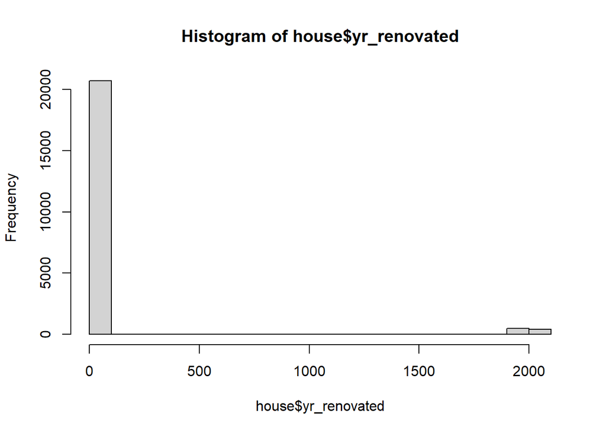

```r
x <- unique(house$yr_renovated)
hist(house$yr_renovated)
```

```r
is.null(house)
```

```
## [1] FALSE
```

```r
col_order <- c("price", "bedrooms", "bathrooms", "floors", "waterfront", "view", "condition", "grade", "yr_built",
               "yr_renovated", "sqft_living", "sqft_lot", "sqft_living15", "sqft_lot15")
house <- house[, col_order]
head(house)
```

```
##     price bedrooms bathrooms floors waterfront view condition grade yr_built
## 1  221900        3      1.00      1          0    0         3     7     1955
## 2  538000        3      2.25      2          0    0         3     7     1951
## 3  180000        2      1.00      1          0    0         3     6     1933
## 4  604000        4      3.00      1          0    0         5     7     1965
## 5  510000        3      2.00      1          0    0         3     8     1987
## 6 1225000        4      4.50      1          0    0         3    11     2001
##   yr_renovated sqft_living sqft_lot sqft_living15 sqft_lot15
## 1            0        1180     5650          1340       5650
## 2         1991        2570     7242          1690       7639
## 3            0         770    10000          2720       8062
## 4            0        1960     5000          1360       5000
## 5            0        1680     8080          1800       7503
## 6            0        5420   101930          4760     101930
```

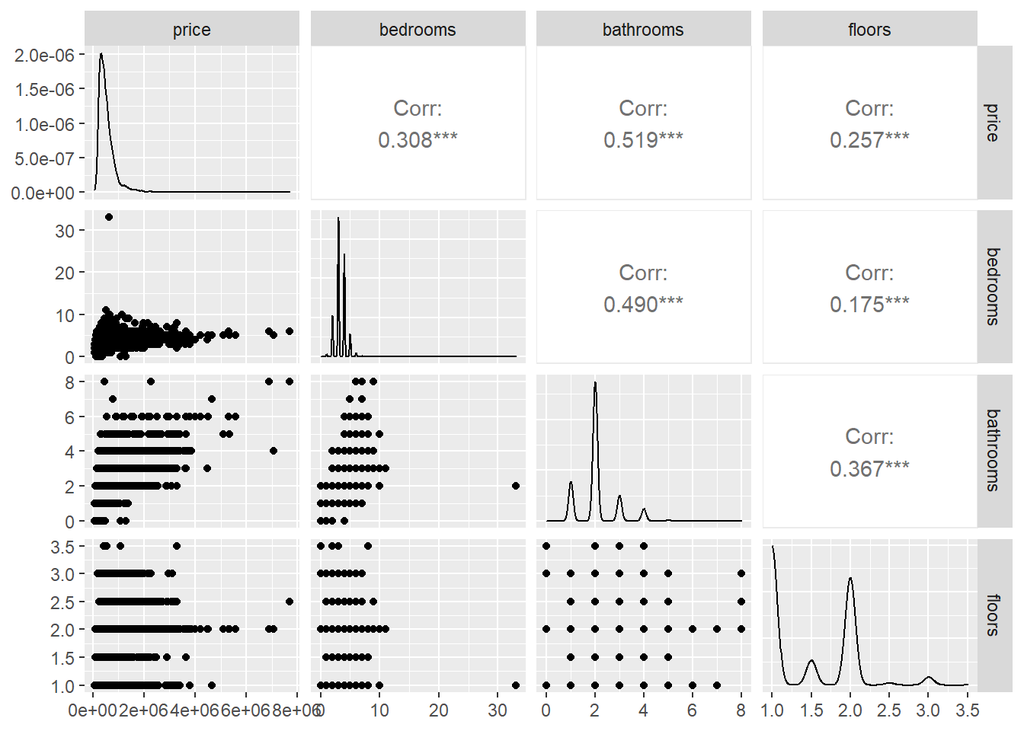

```r
house$bathrooms <- round(house$bathrooms)

house_1 <- house %>% dplyr::select(price, bedrooms, bathrooms, floors)
ggpairs(house_1)
```

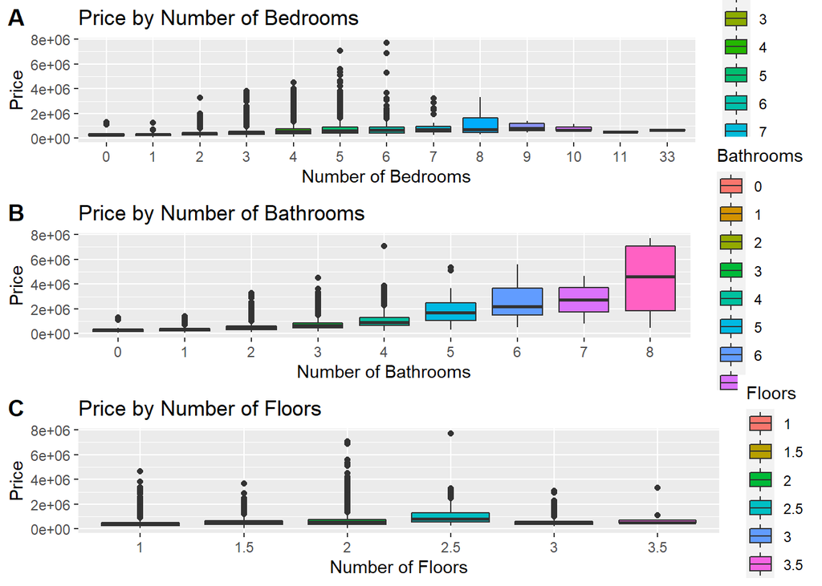

```r
p1 <- ggplot(house, aes(x = as.factor(bedrooms), y = price, fill = as.factor(bedrooms))) +
  geom_boxplot() +
  labs(x = "Number of Bedrooms", y = "Price", title = "Price by Number of Bedrooms", fill = "Bedrooms")

p2 <- ggplot(house, aes(x = as.factor(bathrooms), y = price, fill = as.factor(bathrooms))) +
  geom_boxplot() +
  labs(x = "Number of Bathrooms", y = "Price", title = "Price by Number of Bathrooms", fill = "Bathrooms")

p3 <- ggplot(house, aes(x = as.factor(floors), y = price, fill = as.factor(floors))) +
  geom_boxplot() +
  labs(x = "Number of Floors", y = "Price", title = "Price by Number of Floors", fill = "Floors")

ggarrange(p1, p2, p3,
                    labels = c("A", "B", "C"),
                    ncol = 1, nrow = 3)
```

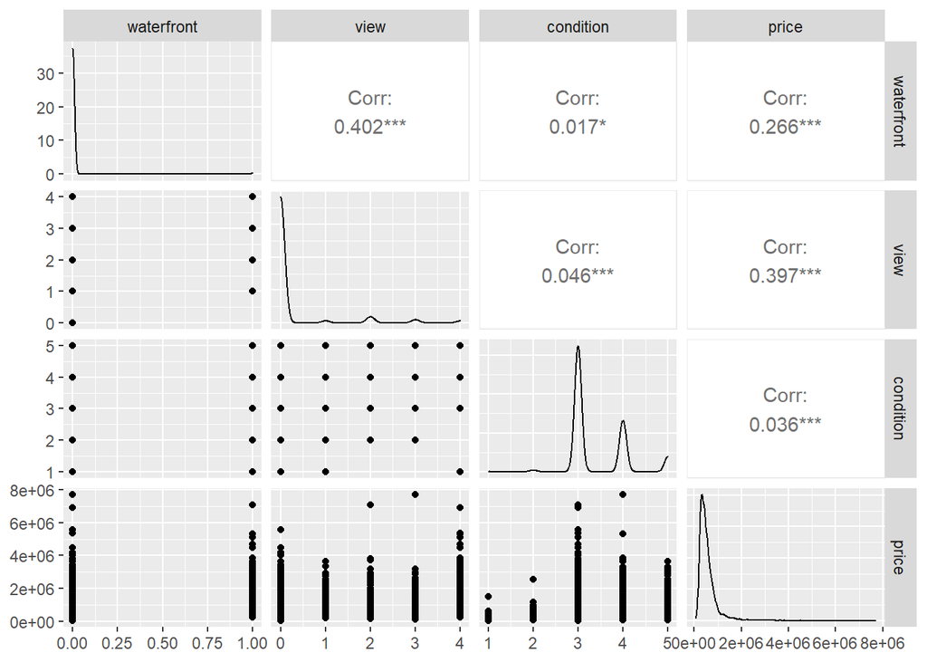

```r
house_2 <- house %>% dplyr::select(waterfront, view, condition, price)
ggpairs(house_2)
```

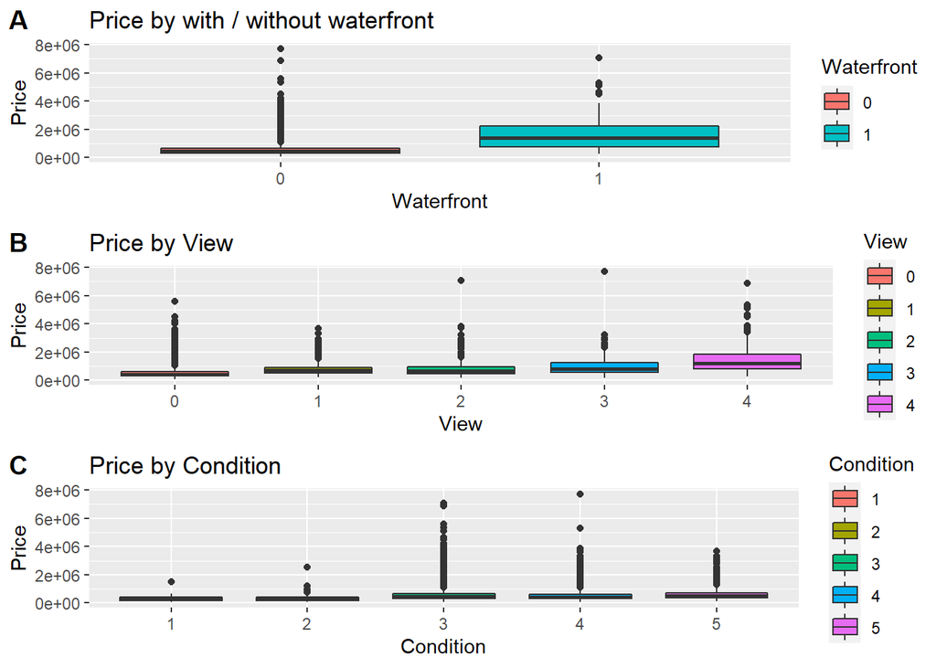

```r
p4 <- ggplot(house, aes(x = as.factor(waterfront), y = price, fill = as.factor(waterfront))) +
  geom_boxplot() +
  labs(x = "Waterfront", y = "Price", title = "Price by with / without waterfront", fill = "Waterfront")

p5 <- ggplot(house, aes(x = as.factor(view), y = price, fill = as.factor(view))) +
  geom_boxplot() +
  labs(x = "View", y = "Price", title = "Price by View", fill = "View")

p6 <- ggplot(house, aes(x = as.factor(condition), y = price, fill = as.factor(condition))) +
  geom_boxplot() +
  labs(x = "Condition", y = "Price", title = "Price by Condition", fill = "Condition")

ggarrange(p4, p5, p6,
                    labels = c("A", "B", "C"),
                    ncol = 1, nrow = 3)
```

```r
house$yr_built <- case_when(
  (1900 <= house$yr_built) &  (house$yr_built< 1920) ~ 0,
  (1920 <= house$yr_built) &  (house$yr_built< 1940) ~ 1,
  (1940 <= house$yr_built) &  (house$yr_built< 1960) ~ 2,
  (1960 <= house$yr_built) &  (house$yr_built< 1980) ~ 3,
  (1980 <= house$yr_built) &  (house$yr_built< 2000) ~ 4,
  (2000 <= house$yr_built) ~ 5)

house$renovated <- ifelse(house$yr_renovated != 0, 1, 0)

house <- house %>% dplyr::select(-yr_renovated)
```

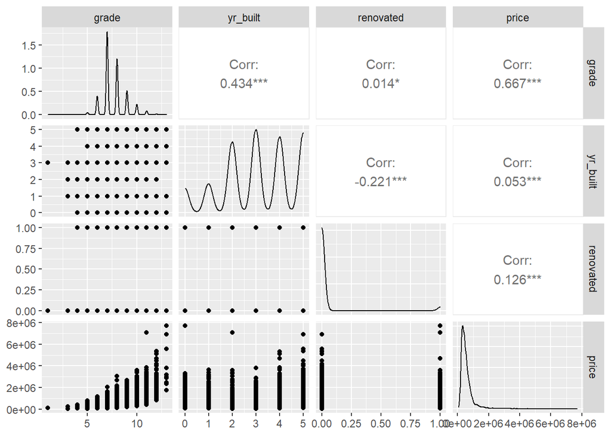

```r
house_3 <- house %>% dplyr::select(grade, yr_built, renovated, price)
ggpairs(house_3)
```

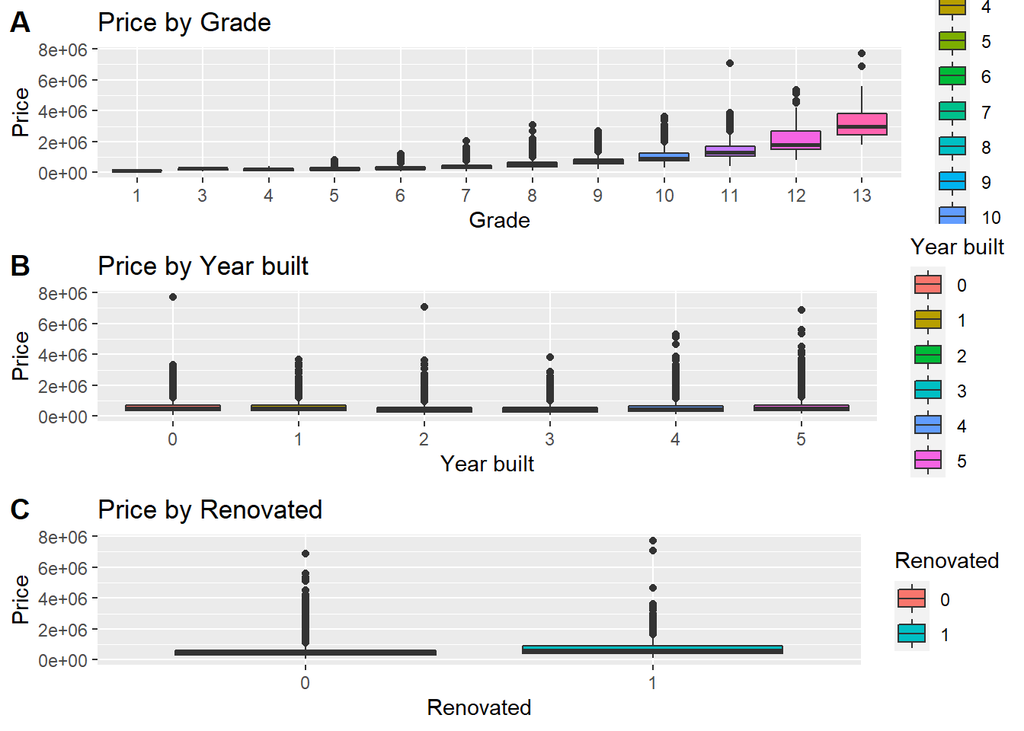

```r
p7 <- ggplot(house, aes(x = as.factor(grade), y = price, fill = as.factor(grade))) +
  geom_boxplot() +
  labs(x = "Grade", y = "Price", title = "Price by Grade", fill = "Grade")

p8 <- ggplot(house, aes(x = as.factor(yr_built), y = price, fill = as.factor(yr_built))) +
  geom_boxplot() +
  labs(x = "Year built", y = "Price", title = "Price by Year built", fill = "Year built")

p9 <- ggplot(house, aes(x = as.factor(renovated), y = price, fill = as.factor(renovated))) +
  geom_boxplot() +
  labs(x = "Renovated", y = "Price", title = "Price by Renovated", fill = "Renovated")

ggarrange(p7, p8, p9,
                    labels = c("A", "B", "C"),
                    ncol = 1, nrow = 3)
```

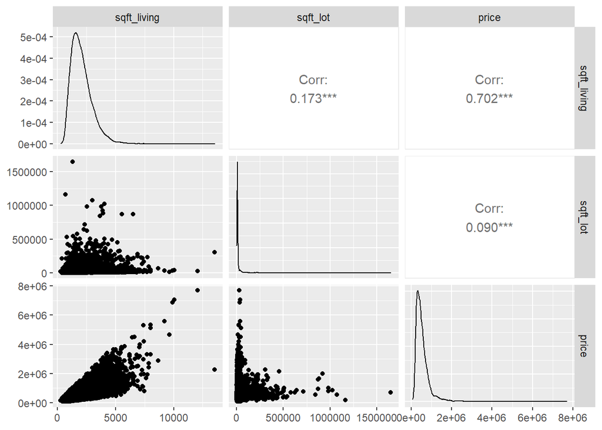

```r
house_4 <- house %>% dplyr::select(sqft_living, sqft_lot, price)
ggpairs(house_4)
```

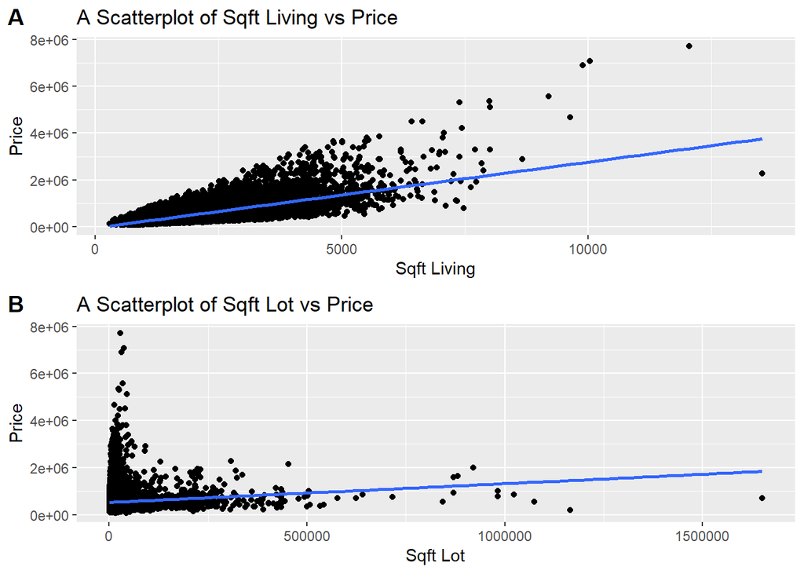

```r
p10 <- ggplot(house, aes(x = sqft_living, y = price)) +
  geom_point() +
  geom_smooth(method = "lm", se = FALSE) +
  labs(x = "Sqft Living", y = "Price", title = "A Scatterplot of Sqft Living vs Price")

p11 <- ggplot(house, aes(x = sqft_lot, y = price)) +
  geom_point() +
  geom_smooth(method = "lm", se = FALSE) +
  labs(x = "Sqft Lot", y = "Price", title = "A Scatterplot of Sqft Lot vs Price")


ggarrange(p10, p11,
                    labels = c("A", "B"),
                    ncol = 1, nrow = 2)
```

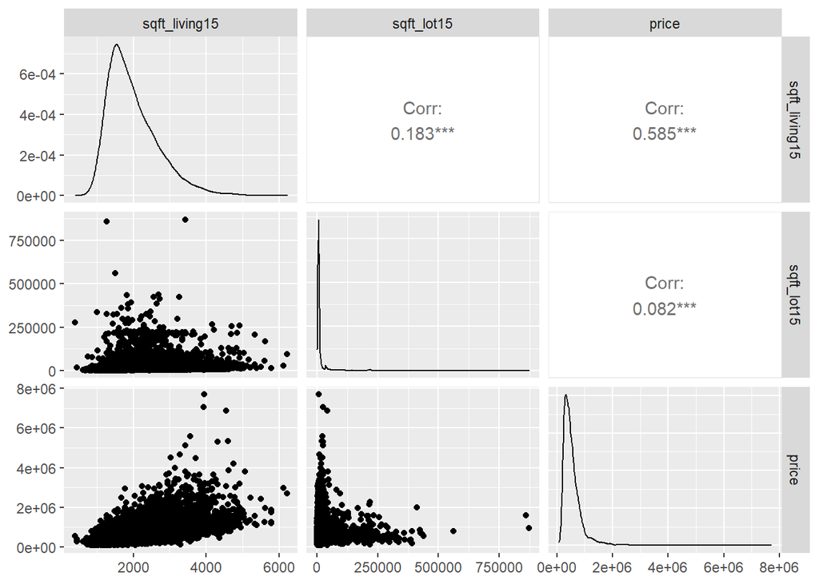

```r
house_5 <- house %>% dplyr::select(sqft_living15, sqft_lot15, price)
ggpairs(house_5)
```

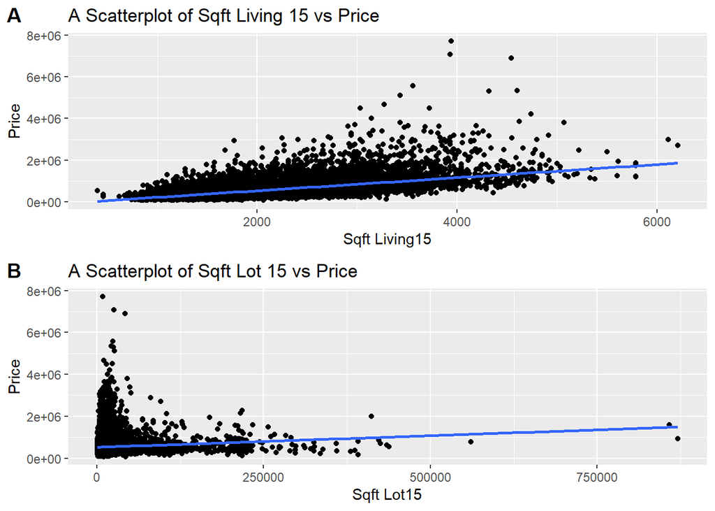

```r
p12 <- ggplot(house, aes(x = sqft_living15, y = price)) +
  geom_point() +
  geom_smooth(method = "lm", se = FALSE) +
  labs(x = "Sqft Living15", y = "Price", title = "A Scatterplot of Sqft Living 15 vs Price")

p13 <- ggplot(house, aes(x = sqft_lot15, y = price)) +
  geom_point() +
  geom_smooth(method = "lm", se = FALSE) +
  labs(x = "Sqft Lot15", y = "Price", title = "A Scatterplot of Sqft Lot 15 vs Price")


ggarrange(p12, p13,
                    labels = c("A", "B"),
                    ncol = 1, nrow = 2)
```

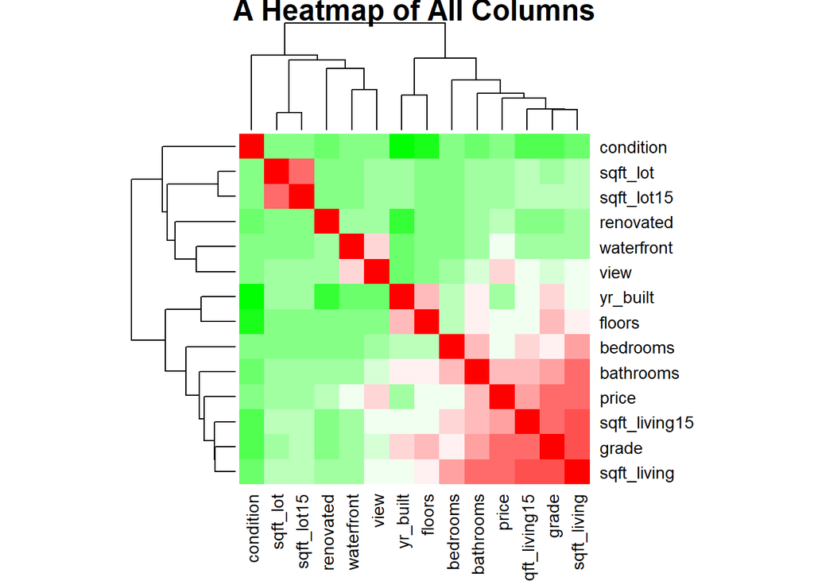

```r
mydata.cor <- cor(house)

palette = colorRampPalette(c("green", "white", "red")) (20)
heatmap(x = mydata.cor, col = palette, symm = TRUE, main = "A Heatmap of All Columns")
```

## 2. Train / Test Split

```r
set.seed(1) ##for reproducibility to get the same split
sample<-sample.int(nrow(house), floor(.80*nrow(house)), replace = F)
train<-house[sample, ] ##training data frame
test<-house[-sample, ] ##test data frame
head(train)
```

```
##        price bedrooms bathrooms floors waterfront view condition grade yr_built
## 17401 550000        3         2    1.5          0    0         3     8        3
## 4775  275000        4         2    2.0          0    0         3     7        4
## 13218 455000        5         2    2.0          0    0         3     6        4
## 10539 384950        3         2    2.0          0    0         3     7        5
## 8462  140000        2         1    1.0          0    0         2     6        2
## 4050  925000        3         2    2.0          0    0         5     7        2
##       sqft_living sqft_lot sqft_living15 sqft_lot15 renovated
## 17401        2910    35200          2590      37500         0
## 4775         2120     6754          2120       6937         0
## 13218        1510     3000          1610       3600         0
## 10539        1860     3690          1870       4394         0
## 8462          900     6400          1350       6405         0
## 4050         2690     7000          1800       6435         0
```

## 3. Modeling

< Stepwise Regression >

```r
regnull <- lm(price ~ 1, data = train)
regfull <- lm(price ~ ., data = train)
step(regnull, scope = list(lower = regnull, upper = regfull), direction = "both")
```

```
## Start:  AIC=442775.7
## price ~ 1
##
##                 Df  Sum of Sq        RSS    AIC
## + sqft_living    1 1.1329e+15 1.1553e+15 430962
## + grade          1 1.0242e+15 1.2640e+15 432516
## + sqft_living15  1 7.8905e+14 1.4992e+15 435466
## + bathrooms      1 6.0414e+14 1.6841e+15 437477
## + view           1 3.5639e+14 1.9318e+15 439850
## + bedrooms       1 2.0920e+14 2.0790e+15 441120
## + waterfront     1 1.7097e+14 2.1172e+15 441435
## + floors         1 1.6137e+14 2.1268e+15 441513
## + renovated      1 3.5656e+13 2.2525e+15 442506
## + sqft_lot       1 2.0037e+13 2.2682e+15 442626
## + sqft_lot15     1 1.5906e+13 2.2723e+15 442657
## + yr_built       1 5.6435e+12 2.2826e+15 442735
## + condition      1 3.4753e+12 2.2847e+15 442751
## <none>                        2.2882e+15 442776
##
## Step:  AIC=430962
## price ~ sqft_living
##
##                 Df  Sum of Sq        RSS    AIC
## + view           1 9.6282e+13 1.0590e+15 429459
## + grade          1 9.6101e+13 1.0592e+15 429462
## + waterfront     1 9.0018e+13 1.0653e+15 429561
## + yr_built       1 6.8189e+13 1.0871e+15 429912
## + bedrooms       1 3.3062e+13 1.1223e+15 430462
## + renovated      1 1.6775e+13 1.1386e+15 430711
## + sqft_living15  1 1.6529e+13 1.1388e+15 430715
## + condition      1 1.3494e+13 1.1418e+15 430761
## + sqft_lot15     1 6.0106e+12 1.1493e+15 430874
## + sqft_lot       1 3.2768e+12 1.1520e+15 430915
## + bathrooms      1 2.3654e+12 1.1530e+15 430929
## + floors         1 3.1999e+11 1.1550e+15 430959
## <none>                        1.1553e+15 430962
## - sqft_living    1 1.1329e+15 2.2882e+15 442776
##
## Step:  AIC=429459.5
## price ~ sqft_living + view
```

[output cut: 200 more lines]

```
##                 Df  Sum of Sq        RSS    AIC
## <none>                        7.9007e+14 424414
## + sqft_lot       1 4.8683e+09 7.9006e+14 424415
## - renovated      1 4.9482e+11 7.9056e+14 424422
## - sqft_living15  1 2.3400e+12 7.9241e+14 424463
## - condition      1 2.9329e+12 7.9300e+14 424476
## - floors         1 3.6017e+12 7.9367e+14 424490
## - sqft_lot15     1 4.5943e+12 7.9466e+14 424512
## - bathrooms      1 8.7444e+12 7.9881e+14 424602
## - view           1 1.2706e+13 8.0278e+14 424687
## - bedrooms       1 1.5062e+13 8.0513e+14 424738
## - waterfront     1 3.8512e+13 8.2858e+14 425234
## - sqft_living    1 8.1831e+13 8.7190e+14 426116
## - yr_built       1 8.9033e+13 8.7910e+14 426258
## - grade          1 9.6056e+13 8.8613e+14 426395
```

```
##
## Call:
## lm(formula = price ~ sqft_living + view + grade + yr_built +
##     waterfront + bedrooms + bathrooms + sqft_lot15 + floors +
##     condition + sqft_living15 + renovated, data = train)
##
## Coefficients:
##   (Intercept)    sqft_living           view          grade       yr_built
##    -6.143e+05      1.635e+02      4.105e+04      1.138e+05     -6.491e+04
##    waterfront       bedrooms      bathrooms     sqft_lot15         floors
##     6.004e+05     -4.016e+04      4.429e+04     -6.069e-01      3.309e+04
##     condition  sqft_living15      renovated
##     2.183e+04      2.810e+01      2.843e+04
```

< Forward Selection >

```r
step(regnull, scope=list(lower=regnull, upper=regfull), direction="forward")
```

```
## Start:  AIC=442775.7
## price ~ 1
##
##                 Df  Sum of Sq        RSS    AIC
## + sqft_living    1 1.1329e+15 1.1553e+15 430962
## + grade          1 1.0242e+15 1.2640e+15 432516
## + sqft_living15  1 7.8905e+14 1.4992e+15 435466
## + bathrooms      1 6.0414e+14 1.6841e+15 437477
## + view           1 3.5639e+14 1.9318e+15 439850
## + bedrooms       1 2.0920e+14 2.0790e+15 441120
## + waterfront     1 1.7097e+14 2.1172e+15 441435
## + floors         1 1.6137e+14 2.1268e+15 441513
## + renovated      1 3.5656e+13 2.2525e+15 442506
## + sqft_lot       1 2.0037e+13 2.2682e+15 442626
## + sqft_lot15     1 1.5906e+13 2.2723e+15 442657
## + yr_built       1 5.6435e+12 2.2826e+15 442735
## + condition      1 3.4753e+12 2.2847e+15 442751
## <none>                        2.2882e+15 442776
##
## Step:  AIC=430962
## price ~ sqft_living
##
##                 Df  Sum of Sq        RSS    AIC
## + view           1 9.6282e+13 1.0590e+15 429459
## + grade          1 9.6101e+13 1.0592e+15 429462
## + waterfront     1 9.0018e+13 1.0653e+15 429561
## + yr_built       1 6.8189e+13 1.0871e+15 429912
## + bedrooms       1 3.3062e+13 1.1223e+15 430462
## + renovated      1 1.6775e+13 1.1386e+15 430711
## + sqft_living15  1 1.6529e+13 1.1388e+15 430715
## + condition      1 1.3494e+13 1.1418e+15 430761
## + sqft_lot15     1 6.0106e+12 1.1493e+15 430874
## + sqft_lot       1 3.2768e+12 1.1520e+15 430915
## + bathrooms      1 2.3654e+12 1.1530e+15 430929
## + floors         1 3.1999e+11 1.1550e+15 430959
## <none>                        1.1553e+15 430962
##
## Step:  AIC=429459.5
## price ~ sqft_living + view
##
```

[output cut: 122 more lines]

```
##     sqft_living15
##
##             Df  Sum of Sq        RSS    AIC
## + renovated  1 4.9482e+11 7.9007e+14 424414
## <none>                    7.9056e+14 424422
## + sqft_lot   1 4.5084e+09 7.9056e+14 424424
##
## Step:  AIC=424413.5
## price ~ sqft_living + view + grade + yr_built + waterfront +
##     bedrooms + bathrooms + sqft_lot15 + floors + condition +
##     sqft_living15 + renovated
##
##            Df  Sum of Sq        RSS    AIC
## <none>                   7.9007e+14 424414
## + sqft_lot  1 4868282009 7.9006e+14 424415
```

```
##
## Call:
## lm(formula = price ~ sqft_living + view + grade + yr_built +
##     waterfront + bedrooms + bathrooms + sqft_lot15 + floors +
##     condition + sqft_living15 + renovated, data = train)
##
## Coefficients:
##   (Intercept)    sqft_living           view          grade       yr_built
##    -6.143e+05      1.635e+02      4.105e+04      1.138e+05     -6.491e+04
##    waterfront       bedrooms      bathrooms     sqft_lot15         floors
##     6.004e+05     -4.016e+04      4.429e+04     -6.069e-01      3.309e+04
##     condition  sqft_living15      renovated
##     2.183e+04      2.810e+01      2.843e+04
```

< Backward Elimination >

```r
step(regfull, scope=list(lower=regnull, upper=regfull), direction="backward")
```

```
## Start:  AIC=424415.4
## price ~ bedrooms + bathrooms + floors + waterfront + view + condition +
##     grade + yr_built + sqft_living + sqft_lot + sqft_living15 +
##     sqft_lot15 + renovated
##
##                 Df  Sum of Sq        RSS    AIC
## - sqft_lot       1 4.8683e+09 7.9007e+14 424414
## <none>                        7.9006e+14 424415
## - renovated      1 4.9518e+11 7.9056e+14 424424
## - sqft_lot15     1 2.3061e+12 7.9237e+14 424464
## - sqft_living15  1 2.3447e+12 7.9241e+14 424465
## - condition      1 2.9358e+12 7.9300e+14 424478
## - floors         1 3.6059e+12 7.9367e+14 424492
## - bathrooms      1 8.7436e+12 7.9881e+14 424604
## - view           1 1.2697e+13 8.0276e+14 424689
## - bedrooms       1 1.5031e+13 8.0510e+14 424739
## - waterfront     1 3.8509e+13 8.2857e+14 425236
## - sqft_living    1 8.1390e+13 8.7146e+14 426109
## - yr_built       1 8.9023e+13 8.7909e+14 426259
## - grade          1 9.6051e+13 8.8612e+14 426397
##
## Step:  AIC=424413.5
## price ~ bedrooms + bathrooms + floors + waterfront + view + condition +
##     grade + yr_built + sqft_living + sqft_living15 + sqft_lot15 +
##     renovated
##
##                 Df  Sum of Sq        RSS    AIC
## <none>                        7.9007e+14 424414
## - renovated      1 4.9482e+11 7.9056e+14 424422
## - sqft_living15  1 2.3400e+12 7.9241e+14 424463
## - condition      1 2.9329e+12 7.9300e+14 424476
## - floors         1 3.6017e+12 7.9367e+14 424490
## - sqft_lot15     1 4.5943e+12 7.9466e+14 424512
## - bathrooms      1 8.7444e+12 7.9881e+14 424602
## - view           1 1.2706e+13 8.0278e+14 424687
## - bedrooms       1 1.5062e+13 8.0513e+14 424738
## - waterfront     1 3.8512e+13 8.2858e+14 425234
## - sqft_living    1 8.1831e+13 8.7190e+14 426116
## - yr_built       1 8.9033e+13 8.7910e+14 426258
## - grade          1 9.6056e+13 8.8613e+14 426395
```

```
##
## Call:
## lm(formula = price ~ bedrooms + bathrooms + floors + waterfront +
##     view + condition + grade + yr_built + sqft_living + sqft_living15 +
##     sqft_lot15 + renovated, data = train)
##
## Coefficients:
##   (Intercept)       bedrooms      bathrooms         floors     waterfront
##    -6.143e+05     -4.016e+04      4.429e+04      3.309e+04      6.004e+05
##          view      condition          grade       yr_built    sqft_living
##     4.105e+04      2.183e+04      1.138e+05     -6.491e+04      1.635e+02
## sqft_living15     sqft_lot15      renovated
##     2.810e+01     -6.069e-01      2.843e+04
```

**< Linear Regression >**

Every predictor but sqft_lot was chosen.

=> Every predictor is statistically significant, but what’s counterintuitive that the sign of coefficient of bedrooms and sqft_lot15 is negative. This implies the prseence of multicollinearity among few columns.

```r
result <- lm(price ~ bedrooms + bathrooms + floors + waterfront + view + condition + grade + yr_built + sqft_living +
               sqft_living15 + sqft_lot15 + renovated, data = train)
summary(result)
```

```
##
## Call:
## lm(formula = price ~ bedrooms + bathrooms + floors + waterfront +
##     view + condition + grade + yr_built + sqft_living + sqft_living15 +
##     sqft_lot15 + renovated, data = train)
##
## Residuals:
##      Min       1Q   Median       3Q      Max
## -1231890  -111153    -8250    91144  4324636
##
## Coefficients:
##                 Estimate Std. Error t value Pr(>|t|)
## (Intercept)   -6.143e+05  1.798e+04 -34.169  < 2e-16 ***
## bedrooms      -4.016e+04  2.213e+03 -18.149  < 2e-16 ***
## bathrooms      4.429e+04  3.203e+03  13.828  < 2e-16 ***
## floors         3.309e+04  3.729e+03   8.875  < 2e-16 ***
## waterfront     6.004e+05  2.069e+04  29.020  < 2e-16 ***
## view           4.105e+04  2.462e+03  16.669  < 2e-16 ***
## condition      2.183e+04  2.726e+03   8.008 1.24e-15 ***
## grade          1.138e+05  2.482e+03  45.831  < 2e-16 ***
## yr_built      -6.491e+04  1.471e+03 -44.124  < 2e-16 ***
## sqft_living    1.635e+02  3.865e+00  42.302  < 2e-16 ***
## sqft_living15  2.810e+01  3.929e+00   7.153 8.81e-13 ***
## sqft_lot15    -6.069e-01  6.055e-02 -10.023  < 2e-16 ***
## renovated      2.843e+04  8.642e+03   3.289  0.00101 **
## ---
## Signif. codes:  0 '***' 0.001 '**' 0.01 '*' 0.05 '.' 0.1 ' ' 1
##
## Residual standard error: 213800 on 17277 degrees of freedom
## Multiple R-squared:  0.6547, Adjusted R-squared:  0.6545
## F-statistic:  2730 on 12 and 17277 DF,  p-value: < 2.2e-16
```

```r
test$predict <- round(predict(result, newdata = test) ^ 10)

test_mse_ln <- mean((test$price - test$predict)^2)
test_mse_ln
```

```
## [1] 1.314601e+125
```

```r
summary(result)$r.squared
```

```
## [1] 0.6547201
```

```r
summary(result)$adj.r.squared
```

```
## [1] 0.6544803
```

```r
PRESS <- function(linear.model) {
  ## get the residuals from the linear.model. ## extract hat from lm.influence to obtain the leverages
  pr <- residuals(linear.model) / (1-lm.influence(linear.model)$hat)
  ## calculate the PRESS by squaring each term and adding them up
  PRESS <- sum(pr ^ 2)
  return(PRESS)
}

PRESS(result)
```

```
## [1] 7.947446e+14
```

```r
##Find SST
anova_result<-anova(result)
SST<-sum(anova_result$"Sum Sq") ##R2 pred
Rsq_pred <- 1-PRESS(result)/SST
Rsq_pred
```

```
## [1] 0.6526771
```

However, according to VIFs, all numbers are below threshold.

```r
library(faraway)
vif(result)
```

```
##      bedrooms     bathrooms        floors    waterfront          view
##      1.607513      2.207145      1.532359      1.198319      1.353198
##     condition         grade      yr_built   sqft_living sqft_living15
##      1.209302      3.208107      1.793612      4.731896      2.740061
##    sqft_lot15     renovated
##      1.065314      1.126851
```

Let’s check residual plot. It seems that linear assumption is violated: constant varaince. Variance gets larger as fitted y gets larger. Therefore, we should implement y transformation to address this issue.

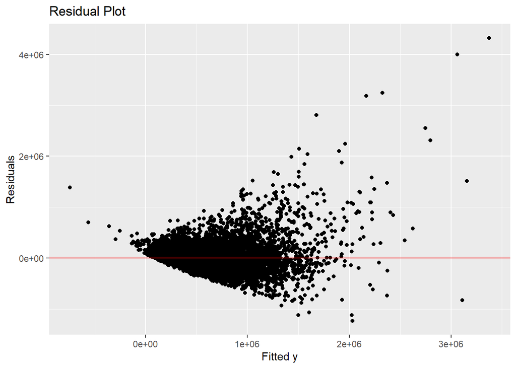

```r
yhat <- result$fitted.values
res <- result$residuals
Data <- data.frame(train, yhat, res)

ggplot(Data, aes(x=yhat,y=res))+
  geom_point()+
  geom_hline(yintercept=0, color="red")+
  labs(x="Fitted y",
       y="Residuals",
       title="Residual Plot")
```

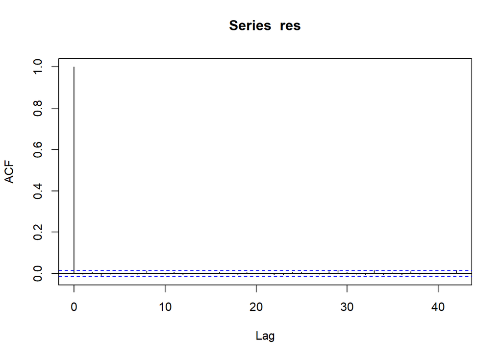

```r
acf(res)
```

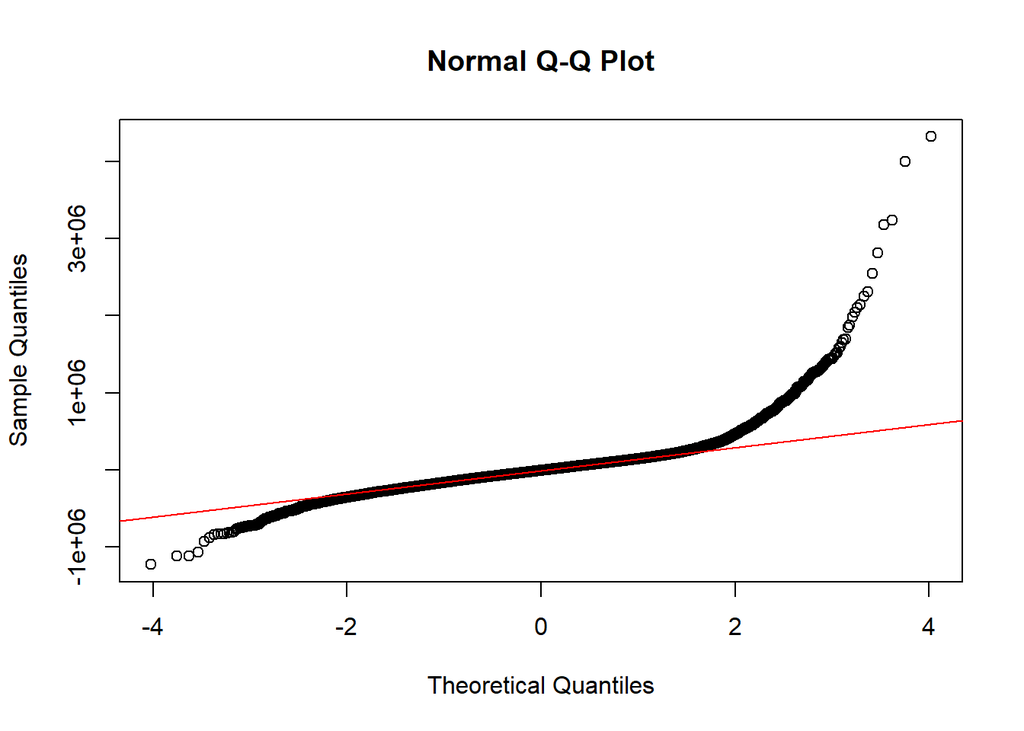

```r
qqnorm(res)
qqline(res, col="red")
```

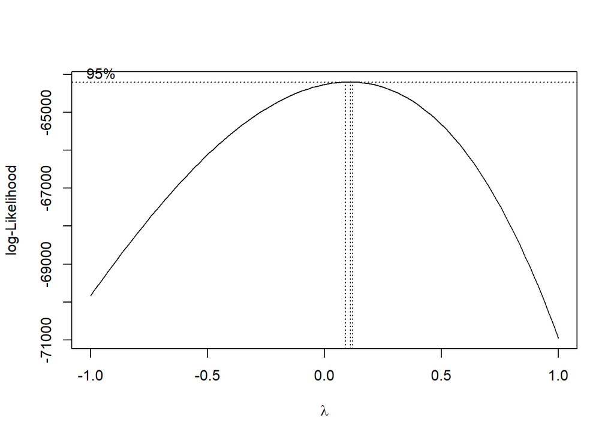

```r
library(MASS)
boxcox(result,lambda = seq(-1.,1,0.5))
```

```r
train <- train %>% mutate(price = price ^ 0.1)
result2 <- lm(price ~ bedrooms + bathrooms + floors + waterfront + view + condition + grade + yr_built + sqft_living +
               sqft_living15 + sqft_lot15 + renovated, data = train)
summary(result2)
```

```
##
## Call:
## lm(formula = price ~ bedrooms + bathrooms + floors + waterfront +
##     view + condition + grade + yr_built + sqft_living + sqft_living15 +
##     sqft_lot15 + renovated, data = train)
##
## Residuals:
##      Min       1Q   Median       3Q      Max
## -0.58082 -0.07908  0.00364  0.07785  0.47712
##
## Coefficients:
##                 Estimate Std. Error t value Pr(>|t|)
## (Intercept)    2.911e+00  9.660e-03 301.295  < 2e-16 ***
## bedrooms      -8.982e-03  1.189e-03  -7.555 4.41e-14 ***
## bathrooms      2.592e-02  1.721e-03  15.062  < 2e-16 ***
## floors         3.859e-02  2.004e-03  19.263  < 2e-16 ***
## waterfront     1.443e-01  1.112e-02  12.981  < 2e-16 ***
## view           1.826e-02  1.323e-03  13.802  < 2e-16 ***
## condition      1.828e-02  1.465e-03  12.479  < 2e-16 ***
## grade          7.377e-02  1.334e-03  55.312  < 2e-16 ***
## yr_built      -3.756e-02  7.904e-04 -47.518  < 2e-16 ***
## sqft_living    5.421e-05  2.077e-06  26.104  < 2e-16 ***
## sqft_living15  3.686e-05  2.111e-06  17.463  < 2e-16 ***
## sqft_lot15    -1.960e-07  3.254e-08  -6.025 1.73e-09 ***
## renovated      1.466e-02  4.643e-03   3.158  0.00159 **
## ---
## Signif. codes:  0 '***' 0.001 '**' 0.01 '*' 0.05 '.' 0.1 ' ' 1
##
## Residual standard error: 0.1149 on 17277 degrees of freedom
## Multiple R-squared:  0.6585, Adjusted R-squared:  0.6583
## F-statistic:  2776 on 12 and 17277 DF,  p-value: < 2.2e-16
```

```r
summary(result2)$r.squared
```

```
## [1] 0.658523
```

```r
summary(result2)$adj.r.squared
```

```
## [1] 0.6582858
```

```r
PRESS(result2)
```

```
## [1] 228.5181
```

```r
##Find SST
anova_result<-anova(result2)
SST<-sum(anova_result$"Sum Sq")

##R2 pred
Rsq_pred <- 1-PRESS(result2)/SST
Rsq_pred
```

```
## [1] 0.6578727
```

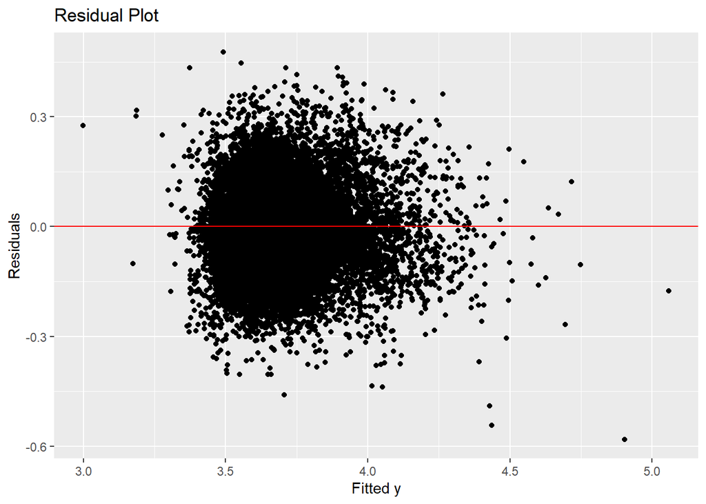

```r
yhat<-result2$fitted.values
res<-result2$residuals
Data<-data.frame(train,yhat,res)

ggplot(Data, aes(x=yhat,y=res))+
  geom_point()+
  geom_hline(yintercept=0, color="red")+
  labs(x="Fitted y",
       y="Residuals",
       title="Residual Plot")
```

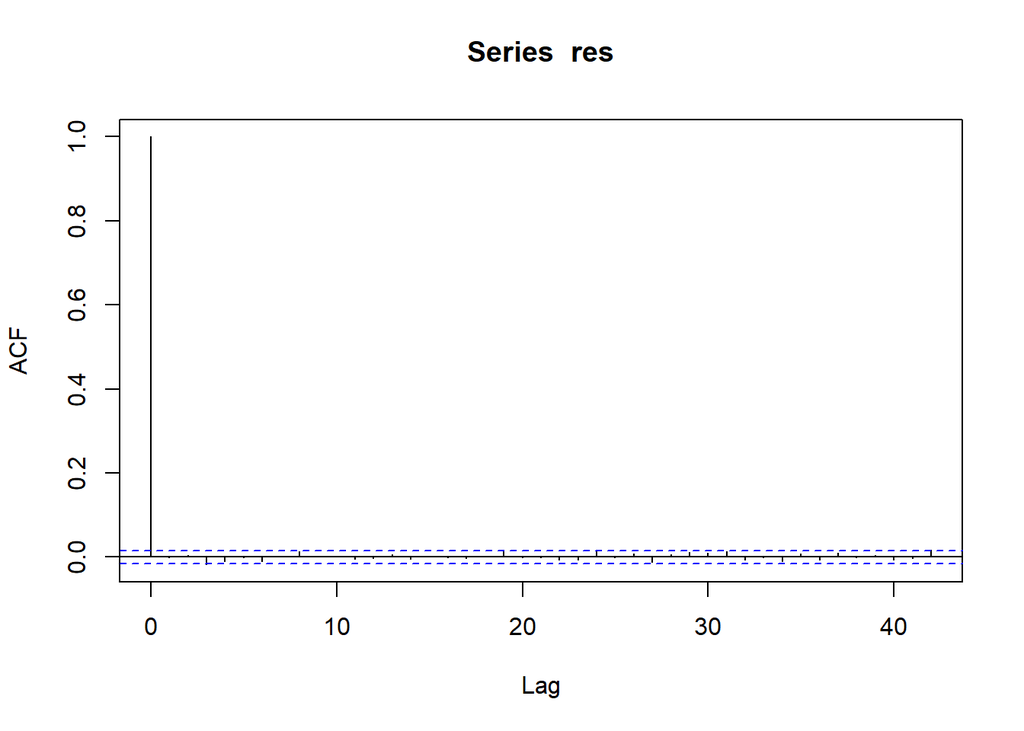

```r
acf(res)
```

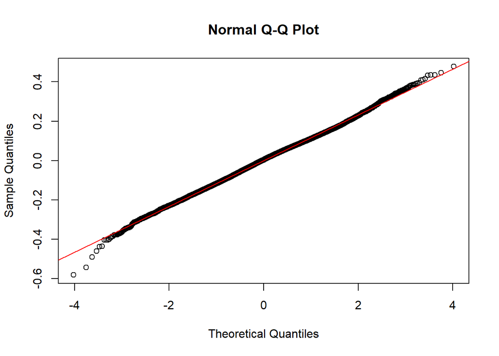

```r
qqnorm(res)
qqline(res, col="red")
```

```r
test$predict <- round(predict(result2, newdata = test) ^ 10)
test_mse_ln_2 <- mean((test$price - test$predict)^2)
test_mse_ln_2
```

```
## [1] 43928749327
```

```r
tail(test)
```

```
##         price bedrooms bathrooms floors waterfront view condition grade
## 21585  380000        3         2      2          0    0         3     7
## 21592  572000        4         3      2          0    0         3     8
## 21594 1088000        5         4      2          0    2         3    10
## 21599  541800        4         2      2          0    2         3     9
## 21602  467000        3         2      3          0    0         3     8
## 21607 1007500        4         4      2          0    0         3     9
##       yr_built sqft_living sqft_lot sqft_living15 sqft_lot15 renovated predict
## 21585        5        1260      900          1310       1415         0  285799
## 21592        5        2770     3852          1810       5641         0  484241
## 21594        5        4170     8142          3030       7980         0 1113250
## 21599        5        3118     7866          2673       6500         0  692559
## 21602        5        1425     1179          1285       1253         0  400368
## 21607        5        3510     7200          2050       6200         0  717624
```

```r
a <- data.frame(price = c(10000, 20000, 30000))
a <- a %>% mutate(boxcox = price^0.1, retransform = boxcox ^ 10)
a
```

```
##   price   boxcox retransform
## 1 10000 2.511886       10000
## 2 20000 2.692173       20000
## 3 30000 2.803575       30000
```

## 4. Identifying Outliers, High Leverage Points, and Influential Points

```r
head(train)
```

```
##          price bedrooms bathrooms floors waterfront view condition grade
## 17401 3.750043        3         2    1.5          0    0         3     8
## 4775  3.498914        4         2    2.0          0    0         3     7
## 13218 3.679604        5         2    2.0          0    0         3     6
## 10539 3.618599        3         2    2.0          0    0         3     7
## 8462  3.270490        2         1    1.0          0    0         2     6
## 4050  3.950155        3         2    2.0          0    0         5     7
##       yr_built sqft_living sqft_lot sqft_living15 sqft_lot15 renovated
## 17401        3        2910    35200          2590      37500         0
## 4775         4        2120     6754          2120       6937         0
## 13218        4        1510     3000          1610       3600         0
## 10539        5        1860     3690          1870       4394         0
## 8462         2         900     6400          1350       6405         0
## 4050         2        2690     7000          1800       6435         0
```

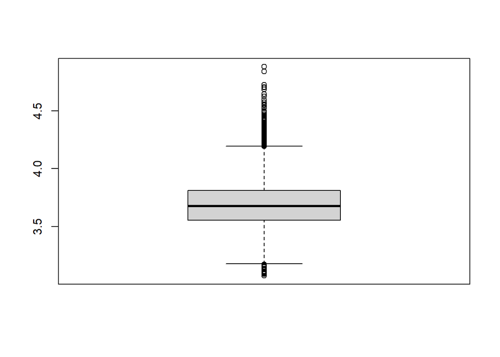

```r
boxplot(train$price)
```

**< Outlier Detection >**

NO Outlier in train data.

```r
n <- nrow(train)
p <- 13
cv <- qt(1-0.05,(2*n), n-1-p)
res <- result2$residuals
standard.res<- res/summary(result2)$sigma
student.res <- rstandard(result2)
ext.student.res <- rstudent(result2)

ext.student.res[abs(ext.student.res)>cv]
```

```
## named numeric(0)
```

```r
res.frame<-data.frame(res,standard.res,
                      student.res,ext.student.res)
```

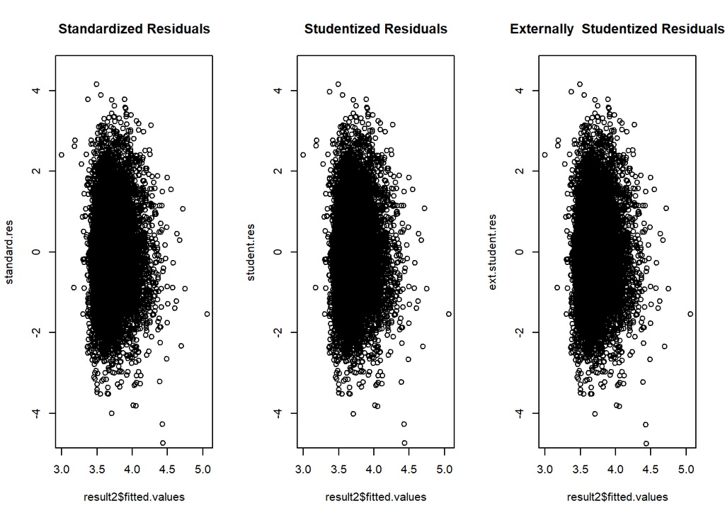

```r
par(mfrow=c(1,3))
plot(result2$fitted.values,standard.res,
     main="Standardized Residuals",
     ylim=c(-4.5,4.5))
plot(result2$fitted.values,student.res,
     main="Studentized Residuals",
     ylim=c(-4.5,4.5))
plot(result2$fitted.values,ext.student.res,
     main="Externally  Studentized Residuals",
     ylim=c(-4.5,4.5))
```

**< Leverage >**

Total 1604 observations (about 9.3 %) are far from the centroid of the predictor space. These high leverage points are potentially to be influential observations.

```r
# leverage
lev <- lm.influence(result2)$hat

# identify high leverage points
x <- lev[lev > 2 * p / n]
length(x) / n
```

```
## [1] 0.09277039
```

< Detecting Influential Observations >

- An observation is problematic only insofar as it “disagrees” with the observation of the data.
- After finding the observations that are outlying / high leverage, the next step is to ascertain whether or not these observations are influential.
- Measures of influence address how much estimates (fitted values, coefficients, etc..) will change if observation was deleted.

```r
# COOK's Distance
COOKS<-cooks.distance(result2)
y <- COOKS[COOKS>qf(0.5,p,n-p)]
length(y)
```

```
## [1] 0
```

```r
# DFFITS (Difference in Fits)
DFFITS <- dffits(result2)
z <- (DFFITS[abs(DFFITS)>2*sqrt(p/n)])
z
```

[output not shown]

[output cut: 255 more lines]

[output not shown]

```r
data.frame(z)
```

```
##                 z
## 18183  0.07108293
## 20728  0.06319248
## 18175  0.05902664
## 13284 -0.05717550
## 19485  0.10840119
## 13973 -0.08076250
## 8547  -0.09930367
## 5936  -0.10606113
## 719    0.06050325
## 5136  -0.05954569
## 9086  -0.14109147
## 14837 -0.07918745
## 12669 -0.07959627
## 5388  -0.10368078
```

[output cut: 914 more lines]

```r
indices <- rownames(data.frame(z))
```

```r
head(train)
```

```
##          price bedrooms bathrooms floors waterfront view condition grade
## 17401 3.750043        3         2    1.5          0    0         3     8
## 4775  3.498914        4         2    2.0          0    0         3     7
## 13218 3.679604        5         2    2.0          0    0         3     6
## 10539 3.618599        3         2    2.0          0    0         3     7
## 8462  3.270490        2         1    1.0          0    0         2     6
## 4050  3.950155        3         2    2.0          0    0         5     7
##       yr_built sqft_living sqft_lot sqft_living15 sqft_lot15 renovated
## 17401        3        2910    35200          2590      37500         0
## 4775         4        2120     6754          2120       6937         0
## 13218        4        1510     3000          1610       3600         0
## 10539        5        1860     3690          1870       4394         0
## 8462         2         900     6400          1350       6405         0
## 4050         2        2690     7000          1800       6435         0
```

```r
rownames(head(train))
```

```
## [1] "17401" "4775"  "13218" "10539" "8462"  "4050"
```

```r
l <- head(train) %>% filter(rownames(head(train)) != 17401)
l <- l %>% filter()
#train[rownames(train) == 17401]
```

```r
train2 <- train
train2$indices <- rownames(train2)
#train2
for (i in indices) {
  train2 <- train2 %>% filter(indices != i)
}

nrow(train2)
```

```
## [1] 16362
```

```r
length(unique(indices))
```

```
## [1] 928
```

```r
nrow(train) - nrow(train2)
```

```
## [1] 928
```

```r
length(indices)
```

```
## [1] 928
```

```r
result3 <- lm(price ~ bedrooms + bathrooms + floors + waterfront + view + condition + grade + yr_built + sqft_living +
               sqft_living15 + sqft_lot15 + renovated, data = train2)
summary(result3)
```

```
##
## Call:
## lm(formula = price ~ bedrooms + bathrooms + floors + waterfront +
##     view + condition + grade + yr_built + sqft_living + sqft_living15 +
##     sqft_lot15 + renovated, data = train2)
##
## Residuals:
##      Min       1Q   Median       3Q      Max
## -0.36488 -0.07307  0.00445  0.07407  0.37689
##
## Coefficients:
##                 Estimate Std. Error t value Pr(>|t|)
## (Intercept)    2.918e+00  9.293e-03 314.005  < 2e-16 ***
## bedrooms      -1.220e-02  1.199e-03 -10.169  < 2e-16 ***
## bathrooms      2.796e-02  1.647e-03  16.975  < 2e-16 ***
## floors         4.394e-02  1.872e-03  23.472  < 2e-16 ***
## waterfront     1.508e-01  1.470e-02  10.260  < 2e-16 ***
## view           1.966e-02  1.324e-03  14.847  < 2e-16 ***
## condition      1.784e-02  1.376e-03  12.969  < 2e-16 ***
## grade          7.446e-02  1.279e-03  58.220  < 2e-16 ***
## yr_built      -4.079e-02  7.413e-04 -55.021  < 2e-16 ***
## sqft_living    5.526e-05  2.094e-06  26.394  < 2e-16 ***
## sqft_living15  3.414e-05  2.099e-06  16.264  < 2e-16 ***
## sqft_lot15    -2.928e-07  3.788e-08  -7.731 1.13e-14 ***
## renovated      1.110e-02  4.850e-03   2.289   0.0221 *
## ---
## Signif. codes:  0 '***' 0.001 '**' 0.01 '*' 0.05 '.' 0.1 ' ' 1
##
## Residual standard error: 0.1033 on 16349 degrees of freedom
## Multiple R-squared:  0.6727, Adjusted R-squared:  0.6725
## F-statistic:  2801 on 12 and 16349 DF,  p-value: < 2.2e-16
```

```r
test$predict <- round(predict(result3, newdata = test) ^ 10)
test_mse_ln_3 <- mean((test$price - test$predict)^2)
test_mse_ln_3
```

```
## [1] 44104007128
```

```r
summary(result3)$r.squared
```

```
## [1] 0.6727283
```

```r
summary(result3)$adj.r.squared
```

```
## [1] 0.6724881
```

```r
PRESS(result3)
```

```
## [1] 174.7996
```

```r
##Find SST
anova_result<-anova(result3)
SST <- sum(anova_result$"Sum Sq")

##R2 pred
Rsq_pred <- 1-PRESS(result3)/SST
Rsq_pred
```

```
## [1] 0.6723251
```

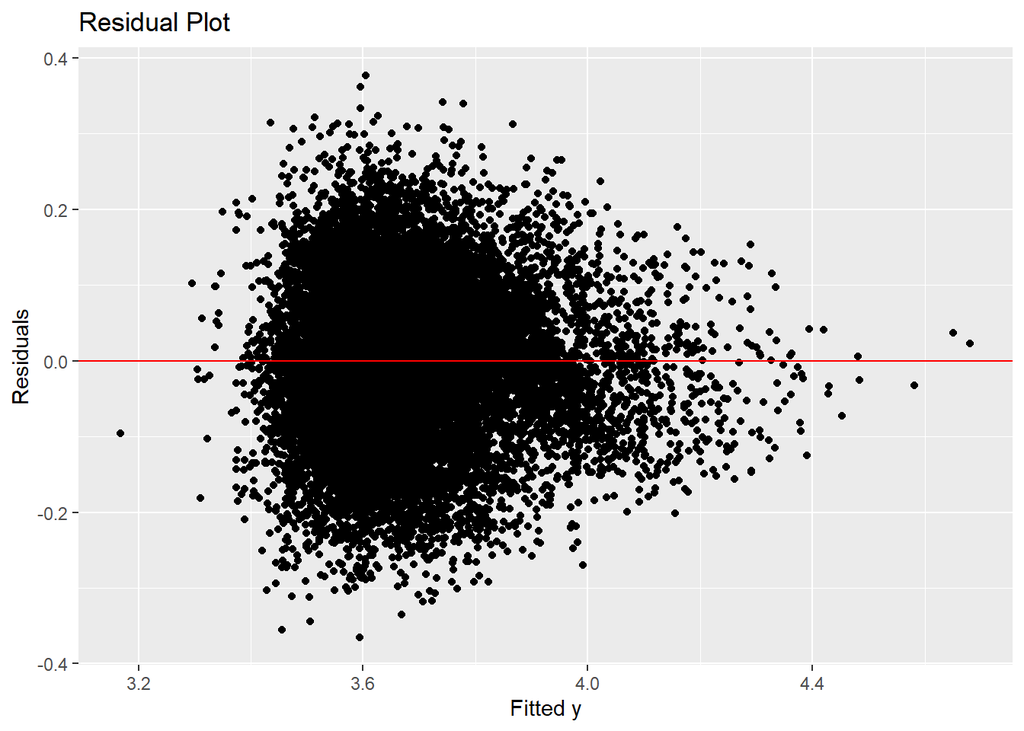

```r
yhat<-result3$fitted.values
res<-result3$residuals
Data<-data.frame(train2,yhat,res)

ggplot(Data, aes(x=yhat,y=res))+
  geom_point()+
  geom_hline(yintercept=0, color="red")+
  labs(x="Fitted y",
       y="Residuals",
       title="Residual Plot")
```

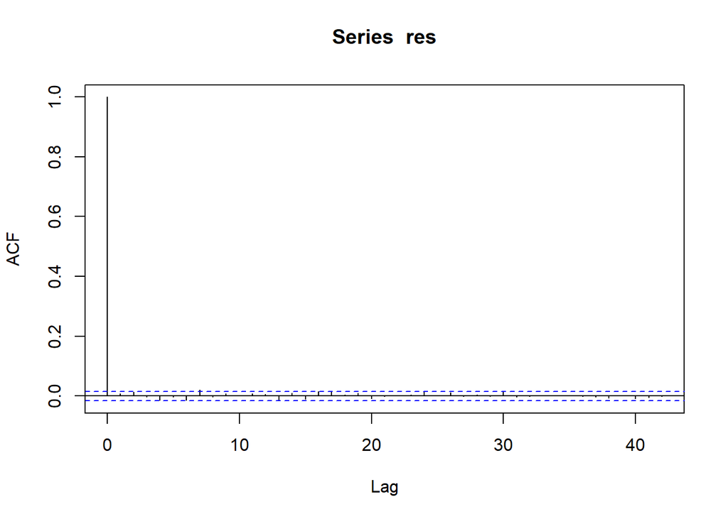

```r
acf(res)
```

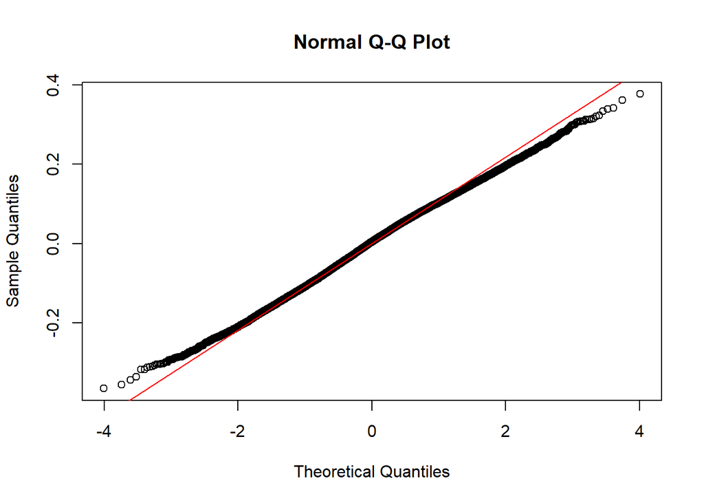

```r
qqnorm(res)
qqline(res, col="red")
```

```r
vif(result3)
```

```
##      bedrooms     bathrooms        floors    waterfront          view
##      1.683463      2.093926      1.560657      1.109195      1.231753
##     condition         grade      yr_built   sqft_living sqft_living15
##      1.228025      3.110906      1.808906      4.792639      2.929764
##    sqft_lot15     renovated
##      1.074602      1.100928
```

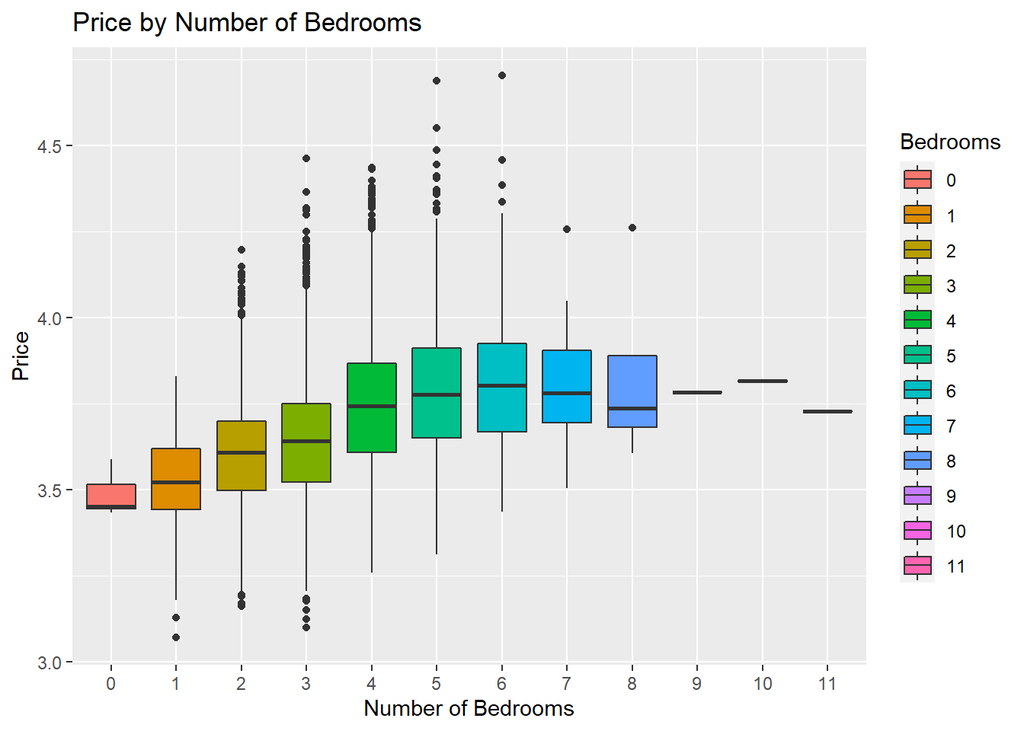

```r
ggplot(train2, aes(x = as.factor(bedrooms), y = price, fill = as.factor(bedrooms))) +
  geom_boxplot() +
  labs(x = "Number of Bedrooms", y = "Price", title = "Price by Number of Bedrooms", fill = "Bedrooms")
```

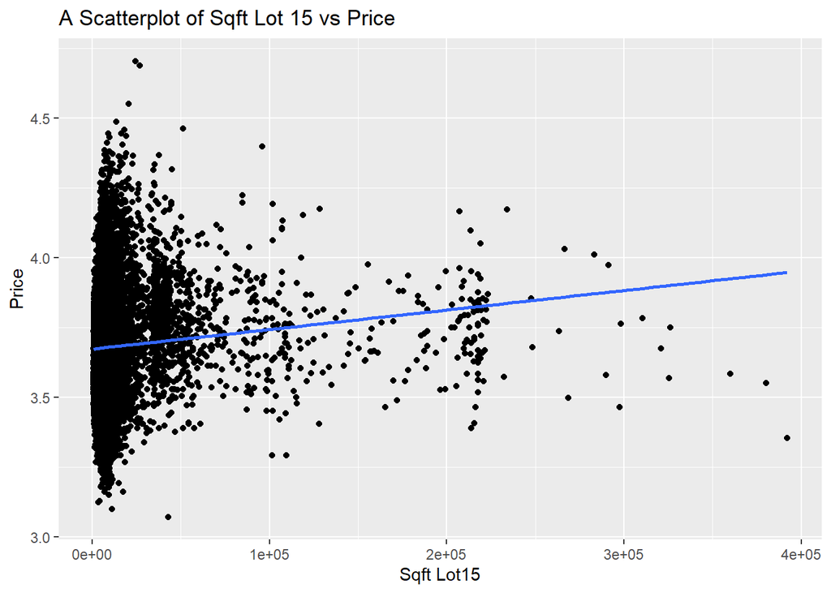

```r
ggplot(train2, aes(x = sqft_lot15, y = price)) +
  geom_point() +
  geom_smooth(method = "lm", se = FALSE) +
  labs(x = "Sqft Lot15", y = "Price", title = "A Scatterplot of Sqft Lot 15 vs Price")
```

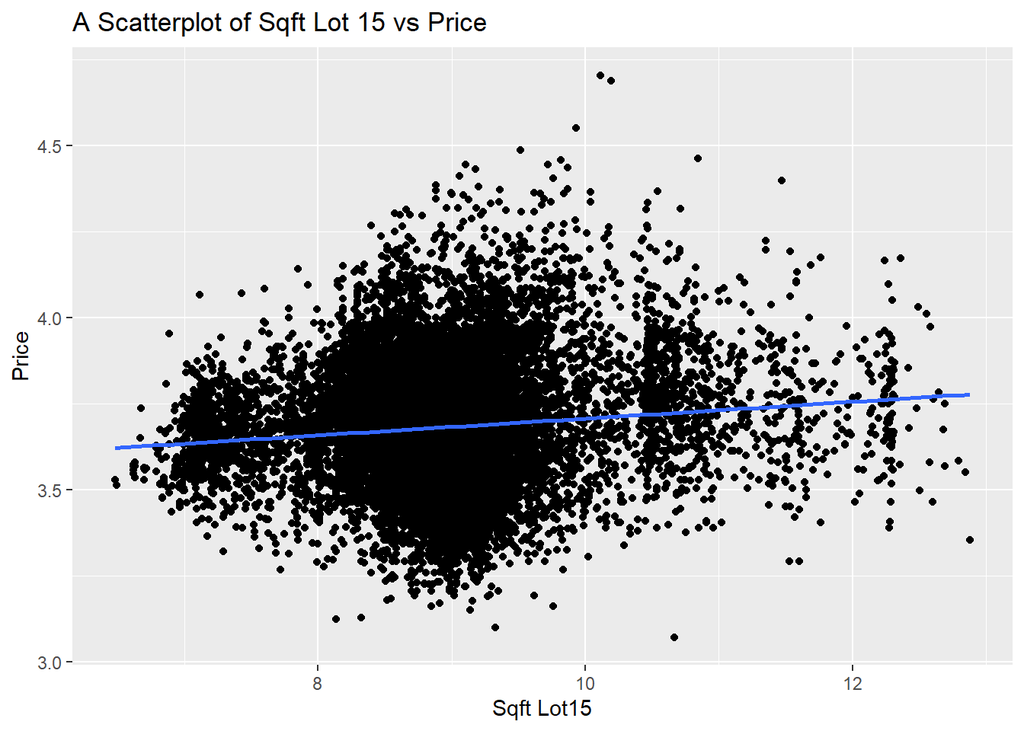

```r
ggplot(train2, aes(x = log(sqft_lot15), y = price)) +
  geom_point() +
  geom_smooth(method = "lm", se = FALSE) +
  labs(x = "Sqft Lot15", y = "Price", title = "A Scatterplot of Sqft Lot 15 vs Price")
```

```r
result4 <- lm(price ~ bedrooms + bathrooms + floors + waterfront + view + condition + grade + yr_built + sqft_living +
               sqft_living15 + log(sqft_lot15) + renovated, data = train2)
summary(result4)
```

```
##
## Call:
## lm(formula = price ~ bedrooms + bathrooms + floors + waterfront +
##     view + condition + grade + yr_built + sqft_living + sqft_living15 +
##     log(sqft_lot15) + renovated, data = train2)
##
## Residuals:
##      Min       1Q   Median       3Q      Max
## -0.35417 -0.07130  0.00412  0.07211  0.38181
##
## Coefficients:
##                   Estimate Std. Error t value Pr(>|t|)
## (Intercept)      3.160e+00  1.418e-02 222.882  < 2e-16 ***
## bedrooms        -1.155e-02  1.178e-03  -9.799  < 2e-16 ***
## bathrooms        2.370e-02  1.637e-03  14.478  < 2e-16 ***
## floors           2.861e-02  1.980e-03  14.448  < 2e-16 ***
## waterfront       1.684e-01  1.452e-02  11.599  < 2e-16 ***
## view             1.838e-02  1.307e-03  14.065  < 2e-16 ***
## condition        1.931e-02  1.359e-03  14.214  < 2e-16 ***
## grade            7.324e-02  1.262e-03  58.029  < 2e-16 ***
## yr_built        -3.961e-02  7.329e-04 -54.039  < 2e-16 ***
## sqft_living      6.243e-05  2.089e-06  29.882  < 2e-16 ***
## sqft_living15    4.404e-05  2.122e-06  20.754  < 2e-16 ***
## log(sqft_lot15) -2.787e-02  1.228e-03 -22.698  < 2e-16 ***
## renovated        1.568e-02  4.788e-03   3.275  0.00106 **
## ---
## Signif. codes:  0 '***' 0.001 '**' 0.01 '*' 0.05 '.' 0.1 ' ' 1
##
## Residual standard error: 0.1019 on 16349 degrees of freedom
## Multiple R-squared:  0.6816, Adjusted R-squared:  0.6813
## F-statistic:  2916 on 12 and 16349 DF,  p-value: < 2.2e-16
```

```r
test$predict <- round(predict(result4, newdata = test) ^ 10)
test_mse_ln_4 <- mean((test$price - test$predict)^2)
test_mse_ln_4
```

```
## [1] 43387370710
```

```r
summary(result4)$r.squared
```

```
## [1] 0.6815662
```

```r
summary(result4)$adj.r.squared
```

```
## [1] 0.6813325
```

```r
PRESS(result4)
```

```
## [1] 170.087
```

```r
##Find SST
anova_result<-anova(result4)
SST <- sum(anova_result$"Sum Sq")

##R2 pred
Rsq_pred <- 1-PRESS(result4)/SST
Rsq_pred
```

```
## [1] 0.6811591
```

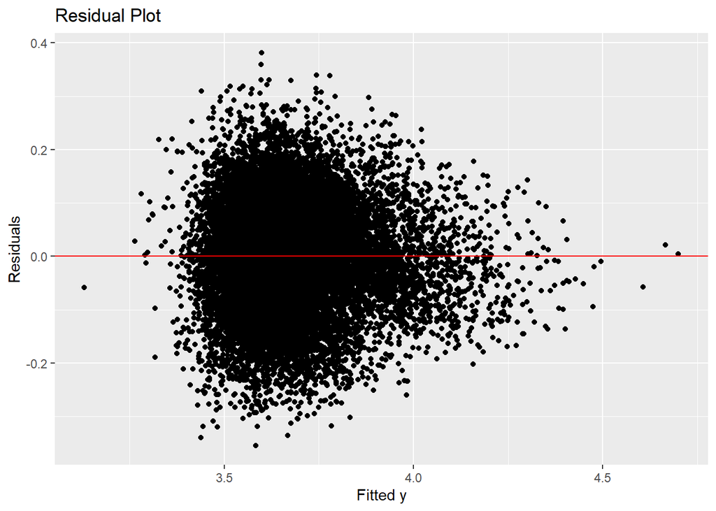

```r
yhat<-result4$fitted.values
res<-result4$residuals
Data<-data.frame(train2,yhat,res)

ggplot(Data, aes(x=yhat,y=res))+
  geom_point()+
  geom_hline(yintercept=0, color="red")+
  labs(x="Fitted y",
       y="Residuals",
       title="Residual Plot")
```

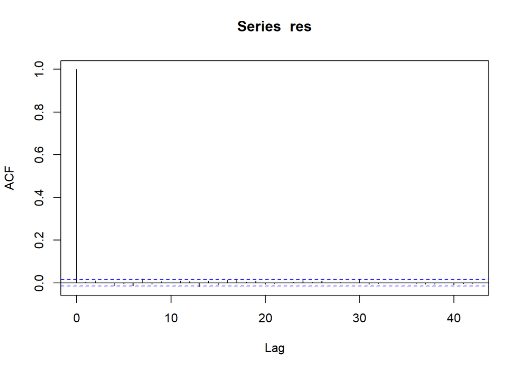

```r
acf(res)
```

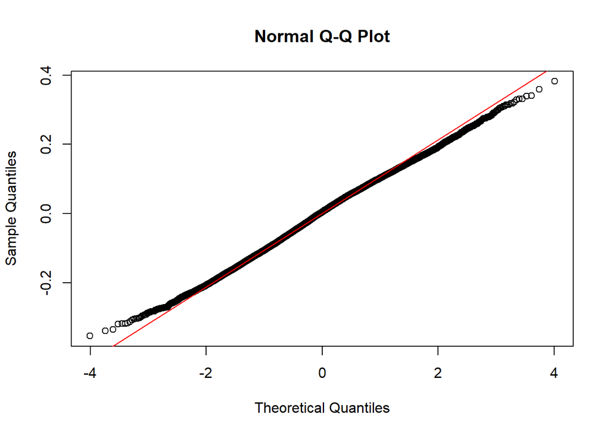

```r
qqnorm(res)
qqline(res, col="red")
```

```r
vif(result4)
```

```
##        bedrooms       bathrooms          floors      waterfront            view
##        1.670024        2.125405        1.794334        1.112768        1.234111
##       condition           grade        yr_built     sqft_living   sqft_living15
##        1.231155        3.113223        1.817342        4.904594        3.076865
## log(sqft_lot15)       renovated
##        1.462865        1.102725
```

```r
house2 <- read.csv('kc_house_data.csv')
house2 <- house2 %>% dplyr::select(-id, -date, -lat, -long)

house2$yr_built <- case_when(
  (1900 <= house2$yr_built) &  (house2$yr_built< 1920) ~ 0,
  (1920 <= house2$yr_built) &  (house2$yr_built< 1940) ~ 1,
  (1940 <= house2$yr_built) &  (house2$yr_built< 1960) ~ 2,
  (1960 <= house2$yr_built) &  (house2$yr_built< 1980) ~ 3,
  (1980 <= house2$yr_built) &  (house2$yr_built< 2000) ~ 4,
  (2000 <= house2$yr_built) ~ 5)

house2$renovated <- ifelse(house2$yr_renovated != 0, 1, 0)

house2$good_neigh <- ifelse(house2$zipcode %in% good_zip, 1, 0)

house2 <- house2 %>% dplyr::select(-zipcode)


house2 <- house2 %>% dplyr::select(-yr_renovated)
head(house2)
```

```
##     price bedrooms bathrooms sqft_living sqft_lot floors waterfront view
## 1  221900        3      1.00        1180     5650      1          0    0
## 2  538000        3      2.25        2570     7242      2          0    0
## 3  180000        2      1.00         770    10000      1          0    0
## 4  604000        4      3.00        1960     5000      1          0    0
## 5  510000        3      2.00        1680     8080      1          0    0
## 6 1225000        4      4.50        5420   101930      1          0    0
##   condition grade sqft_above sqft_basement yr_built sqft_living15 sqft_lot15
## 1         3     7       1180             0        2          1340       5650
## 2         3     7       2170           400        2          1690       7639
## 3         3     6        770             0        1          2720       8062
## 4         5     7       1050           910        3          1360       5000
## 5         3     8       1680             0        4          1800       7503
## 6         3    11       3890          1530        5          4760     101930
##   renovated good_neigh
## 1         0          0
## 2         1          1
## 3         0          1
## 4         0          1
## 5         0          1
## 6         0          1
```

```r
set.seed(1) ##for reproducibility to get the same split
sample<-sample.int(nrow(house), floor(.80*nrow(house2)), replace = F)
train2 <- house2[sample, ] ##training data frame
test2 <- house2[-sample, ] ##test data frame
head(train2)
```

```
##        price bedrooms bathrooms sqft_living sqft_lot floors waterfront view
## 17401 550000        3      1.75        2910    35200    1.5          0    0
## 4775  275000        4      2.50        2120     6754    2.0          0    0
## 13218 455000        5      2.00        1510     3000    2.0          0    0
## 10539 384950        3      2.50        1860     3690    2.0          0    0
## 8462  140000        2      1.00         900     6400    1.0          0    0
## 4050  925000        3      2.50        2690     7000    2.0          0    0
##       condition grade sqft_above sqft_basement yr_built sqft_living15
## 17401         3     8       2910             0        3          2590
## 4775          3     7       2120             0        4          2120
## 13218         3     6       1510             0        4          1610
## 10539         3     7       1860             0        5          1870
## 8462          2     6        900             0        2          1350
## 4050          5     7       1840           850        2          1800
##       sqft_lot15 renovated good_neigh
## 17401      37500         0          1
## 4775        6937         0          0
## 13218       3600         0          1
## 10539       4394         0          1
## 8462        6405         0          0
## 4050        6435         0          1
```